# Data Analyzi & Visualiz - WeRateDogs

#### By: Abdulwahab Bawahab

## Introduction

#### Analyzing and Visualizing Data

Here we will analyze and visualize our data in twitter archive of the Twitter user **@dog_rates**.

## Analyzing & Visualizing Data

```python
# Import packages
import pandas as pd
%matplotlib inline
import numpy as np
import seaborn as sns
import matplotlib.pyplot as plt
from matplotlib import dates
```

## Load Data

```python
# Load Dataset of twitter archive master
archive_tw = pd.read_csv('twitter_archive_master.csv', encoding = 'utf-8')
archive_tw.head(3)
```

|  | tweet_id | in_reply_to_status_id | in_reply_to_user_id | timestamp | text | expanded_urls | rating_numerator | rating_denominator | name | stages | jpg_url | retweet_count | favorite_count | dog_predict | dog_conf |
| --- | --- | --- | --- | --- | --- | --- | --- | --- | --- | --- | --- | --- | --- | --- | --- |
| 0 | 892177421306343426 | NaN | NaN | 2017-08-01 00:17:27 +0000 | This is Tilly. She's just checking pup on you.... | https://twitter.com/dog_rates/status/892177421... | 13.0 | 10 | Tilly | NaN | https://pbs.twimg.com/media/DGGmoV4XsAAUL6n.jpg | 6514 | 33819 | chihuahua | 0.323581 |
| 1 | 891815181378084864 | NaN | NaN | 2017-07-31 00:18:03 +0000 | This is Archie. He is a rare Norwegian Pouncin... | https://twitter.com/dog_rates/status/891815181... | 12.0 | 10 | Archie | NaN | https://pbs.twimg.com/media/DGBdLU1WsAANxJ9.jpg | 4328 | 25461 | chihuahua | 0.716012 |
| 2 | 891689557279858688 | NaN | NaN | 2017-07-30 15:58:51 +0000 | This is Darla. She commenced a snooze mid meal... | https://twitter.com/dog_rates/status/891689557... | 13.0 | 10 | Darla | NaN | https://pbs.twimg.com/media/DF_q7IAWsAEuuN8.jpg | 8964 | 42908 | labrador retriever | 0.168086 |

### 1.Insight

#### We want to see the count of dogs stages in the tweets and what stage showing as the most in WeRateDogs Twitter account.

```python
# count of the dog stages column
dog_stages = archive_tw['stages'].value_counts()
dog_stages
```

```
pupper            168
doggo              54
puppo              21
doggo, pupper       8
floofer             7
doggo, floofer      1
doggo, puppo        1
Name: stages, dtype: int64
```

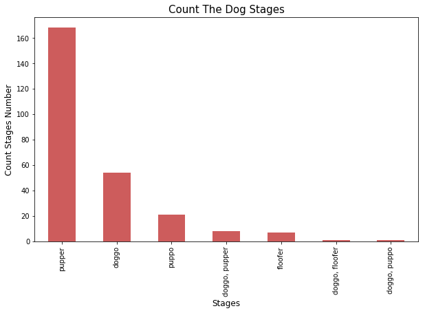

```python
# plot bar for count of the dogs stages

dog_stages.plot(kind='bar', figsize=(10,6), color='#CD5C5C')
plt.title("Count The Dog Stages", fontsize=15, color='black')
plt.xlabel("Stages" ,fontsize=12, color='black')
plt.ylabel("Count Stages Number" ,fontsize=12, color='black');

# save
plt.savefig('Count_Dogs_Stages', dpi=80, bbox_inches='tight');
```

### Conclusion

We find in our analysis that the **Pupper** dog stages are the most common rating in the **WeRateDogs** Twitter account with **168** tweets. And then comes **Doggo** in the second with **54** tweets. Then **Puppo** with **21** tweets and **Floofer** with **7** tweets.

And we find some dogs classcificated under two type **doggo, pupper** with **8** tweets.

And **doggo, floofer** & **doggo, puppo** with one tweet.

We can say that many people prefer young dogs and interested in it than the older one.

### 2.Insight

#### We want to see the count of dogs types in the tweets and the most type in WeRateDogs Twitter account.

```python
# the dog type count

predic = archive_tw['dog_predict'].value_counts()
predic
```

```
golden retriever                  158
labrador retriever                108
pembroke                           95
chihuahua                          91
pug                                62
toy poodle                         51
chow                               48
pomeranian                         42
samoyed                            42
malamute                           33
french bulldog                     31
chesapeake bay retriever           31
cocker spaniel                     30
miniature pinscher                 25
eskimo dog                         22
german shepherd                    21
staffordshire bullterrier          21
cardigan                           21
shih-tzu                           20
siberian husky                     20
beagle                             20
shetland sheepdog                  19
rottweiler                         19
maltese dog                        19
kuvasz                             18
lakeland terrier                   18
basset                             17
italian greyhound                  17
american staffordshire terrier     16
west highland white terrier        16
                                 ...
welsh springer spaniel              4
scottish deerhound                  4
tibetan terrier                     4
rhodesian ridgeback                 4
irish setter                        4
keeshond                            4
cairn                               3
irish water spaniel                 3
greater swiss mountain dog          3
komondor                            3
brabancon griffon                   3
curly-coated retriever              3
afghan hound                        3
toy terrier                         3
briard                              3
leonberg                            3
black-and-tan coonhound             2
sussex spaniel                      2
australian terrier                  2
groenendael                         2
wire-haired fox terrier             2
appenzeller                         2
scotch terrier                      1
clumber                             1
entlebucher                         1
bouvier des flandres                1
silky terrier                       1
standard schnauzer                  1
irish wolfhound                     1
japanese spaniel                    1
Name: dog_predict, Length: 113, dtype: int64
```

```python
top_predic = predic.nlargest(8)
top_predic
```

```
golden retriever      158
labrador retriever    108
pembroke               95
chihuahua              91
pug                    62
toy poodle             51
chow                   48
pomeranian             42
Name: dog_predict, dtype: int64
```

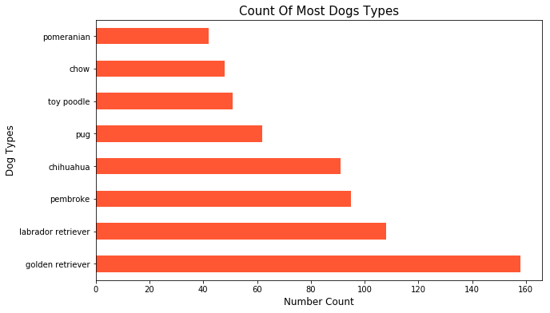

```python
# plot bar horizontal to count the 8 most type of dogs.

top_predic.plot(kind = 'barh', figsize=(10,6), color='#FF5733')
plt.title('Count Of Most Dogs Types', fontsize=15, color = 'black')
plt.xlabel('Number Count', fontsize = 12, color = 'black')
plt.ylabel('Dog Types', fontsize = 12, color = 'black')

# save
plt.savefig('Count_Dogs_types', dpi=80, bbox_inches='tight');
```

### 3.Insight

#### The relationship between retweet count and favorite count.

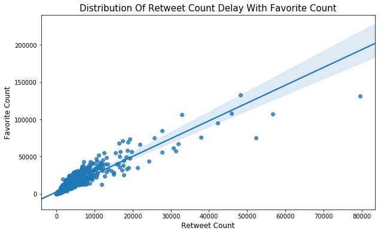

```python
# scutter plots for retweet count with favorite count

plt.figure(figsize = [10, 6])
sns.regplot(data = archive_tw, x = 'retweet_count', y = 'favorite_count');
plt.xlabel('Retweet Count', fontsize = 12, color='black')
plt.ylabel('Favorite Count', fontsize = 12, color='black')
plt.title('Distribution Of Retweet Count Delay With Favorite Count', fontsize = 15, color='black');

# save
plt.savefig('Distribution_RetweetCount_With_FavoriteCount', dpi=80, bbox_inches='tight');
```

### Conclusion

We can see from this plot the relationship between the retweet count and favorite count goes as a **positive correlation**. and as we see there are a big distribution on the little count of the retweet and favorite, but it goes less on the larges one. also, we find the tweets almost always got retweet less than got favorite. And there are few tweets with a big count of retweet and count of the favorite about a 20k retweet and a 70k favorite.